# FPDA Project Mardown

### Data import

```r
data.df = read.csv(paste(basedir, "Projectdata.csv", sep="/"), header = TRUE)
data.df$date = as.Date(data.df$ï..date)
head(data.df)
```

```
##      ï..date Hobbies_CA_1 Household_1_CA_1 Household_2_CA_1 Foods_1_CA_1
## 1 2011-01-29          389              105              114          208
## 2 2011-01-30          381              104              110          210
## 3 2011-01-31          314               96               77          117
## 4 2011-02-01          303               90               66          122
## 5 2011-02-02          184               59               77          109
## 6 2011-02-03          276               87               81          150
##   Foods_2_CA_1 Foods_3_CA_1 Hobbies_CA_2 Household_1_CA_2 Household_2_CA_2
## 1          305         1799          374              169              143
## 2          347         1808          238              152              154
## 3          153         1118          238              105               97
## 4          183         1265          233               84               92
## 5          209         1217          198               73              104
## 6          245         1291          256               62              117
##   Foods_1_CA_2 Foods_2_CA_2 Foods_3_CA_2 Hobbies_CA_3 Household_1_CA_3
## 1           63          274         1260          383              160
## 2           47          209         1066          310              200
## 3           39          123          759          271              168
## 4           49          130          904          309              174
## 5           20          112          787          233              141
## 6           29          160          937          206              160
##   Household_2_CA_3 Foods_1_CA_3 Foods_2_CA_3 Foods_3_CA_3       date
## 1              176          188          307         2029 2011-01-29
## 2              204          240          341         2035 2011-01-30
## 3              148          183          278         1535 2011-01-31
## 4              160          185          337         1900 2011-02-01
## 5              150          162          290         1699 2011-02-02
## 6              132          191          349         2019 2011-02-03
```

## 1. STATIONARITY

### a) Plots and ACF & PACF

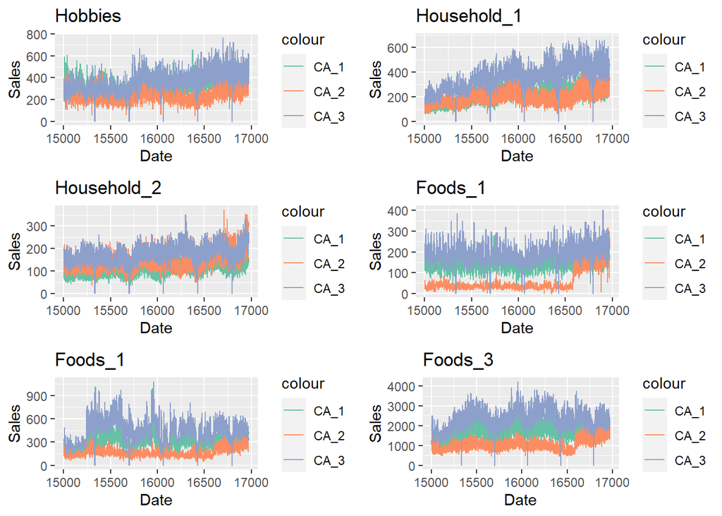

ACF and PACF for the ‘Hobbies’ item:

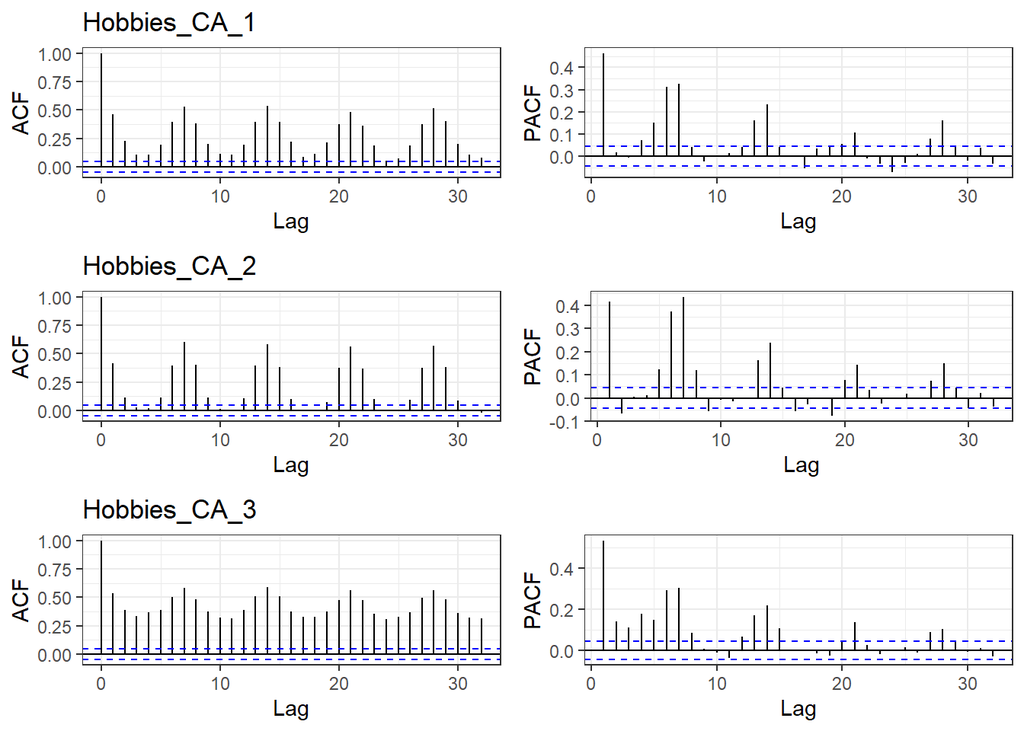

### b) Unit root test

The following piece of code applies the Dickey-Fuller test to the first column of the dataset ‘Hobbies_CA_1’:

```r
library(urca)
test = ur.df(data.df$Hobbies_CA_1, type = "drift", selectlags = "AIC")
summary(test)
```

```
##
## ###############################################
## # Augmented Dickey-Fuller Test Unit Root Test #
## ###############################################
##
## Test regression drift
##
##
## Call:
## lm(formula = z.diff ~ z.lag.1 + 1 + z.diff.lag)
##
## Residuals:
##     Min      1Q  Median      3Q     Max
## -348.26  -51.55   -4.66   51.62  364.03
##
## Coefficients:
##              Estimate Std. Error t value Pr(>|t|)
## (Intercept) 170.18477    7.76921  21.905   <2e-16 ***
## z.lag.1      -0.52529    0.02335 -22.493   <2e-16 ***
## z.diff.lag   -0.01850    0.02258  -0.819    0.413
## ---
## Signif. codes:  0 '***' 0.001 '**' 0.01 '*' 0.05 '.' 0.1 ' ' 1
##
## Residual standard error: 78.43 on 1964 degrees of freedom
## Multiple R-squared:  0.2678, Adjusted R-squared:  0.2671
## F-statistic: 359.2 on 2 and 1964 DF,  p-value: < 2.2e-16
##
##
## Value of test-statistic is: -22.4928 252.9627
##
## Critical values for test statistics:
##       1pct  5pct 10pct
## tau2 -3.43 -2.86 -2.57
## phi1  6.43  4.59  3.78
```

## 2. Benchmark of models

To get the forecasts from the different models, the models are run at once on all columns of the training data and then the forecast on the testing data is stored in one CSV file per model. The training and testing time series are also stored in CSV files which have the same format as the input data (which is the same as the model files too).

Three different splits are done in order to validate that the results of a model do not depend on the split of the data. The three splits are 70%/30%, 80%/20% and 90%/10%, where x%/y% means that the first x% of the data is used to fit the model and the y% remaining is used to assess the models. The forecasts for each splits are stored in different folders.

The following results are shown first for the 80%/20% split.

```r
split = 0.8
inputdir = paste(basedir, "forecasts", sep="/")
if (split == 0.9) {
  inputdir = paste(inputdir, "90", sep = "_")
}
if (split == 0.7) {
  inputdir = paste(inputdir, "70", sep = "_")
}

train.df = read.csv(paste(inputdir, "train.csv", sep="/"), header = TRUE)
test.df = read.csv(paste(inputdir, "test.csv", sep="/"), header = TRUE)
```

To assess the quality of the forecast, the Root Mean Squared Scaled Error (RMSSE) defined in the M5 guidelines is used. The following function allows to compute it from the training set time series, the predictions on the testing set and the testing set time series.

The main reason for the use of this error function is its invariance to scale. Which allows us to use it to compare results on time series with different scalings.

```r
# RMSSE
rmsse <- function(train, pred, truth) {

  if (class(pred) == "forecast") {
    pred = pred$mean
  }

  rmse = sum((pred - truth)**2) / length(pred)
  rmse = rmse**0.5

  train.length = length(train)
  denom = sum((train[1: train.length-1] - train[2: train.length])**2) / (train.length - 1)
  rmsse = rmse / denom**0.5

  rmsse
}
```

### a) Statistical benchmarks

Each model is fitted on the training set, used to forecast on the testing set and evaluated in the same function. For example, the following code shows the function for the Naive model:

```r
# naive forecast
naive.forecast <- function(df, split = 0.8, h = NULL, exclude = NULL, frequency = 365) {

  train_indices <- seq_len(length.out = floor(x = split * nrow(x = df)))
  train.df <- df[train_indices,]
  train.length = nrow(x = train.df)
  test.df <- df[-train_indices,]
  test.length = nrow(x = test.df)

  h = ifelse(is.null(h), test.length, h)
  if (is.null(exclude)) {
    exclude = c(1, length(colnames(df)))
  }

  out.df = data.frame(date=test.df$date)
  out.eval = data.frame(Loss=c("RMSE", "MAE", "RMSSE", "Train_RMSE", "Train_MAE"))

  for (i in 1:length(colnames(df))){
    if (!is.element(i, exclude)){
      colname = colnames(df)[i]
      x = ts(train.df[colname], start=train.df$date[1], frequency = frequency)
      truth = ts(test.df[colname], start=test.df$date[1], frequency = frequency)[seq(1, h, 1)]
      naive.forecast = naive(x, h = h)
      out.df[colname] = naive.forecast$mean
      col.eval = eval(naive.forecast, truth)
      out.eval[colname] = c(col.eval[2, 2],
                            col.eval[2, 3],
                            rmsse(x, naive.forecast, truth),
                            col.eval[1, 2],
                            col.eval[1, 3])
    }
  }

  list("df"= out.df, "eval"=out.eval)
}
```

Only the models with explanatory variables (ESX and SARIMAX) use one more object ‘xreg’ for fitting and forecasting. This object stores the time series of all columns except the one being fitted and forecasted. As shown in the following code which is the function for SARIMAX:

```r
# SARIMAX forecast
sarimax.forecast <- function(df, split = 0.8, h = NULL, exclude = NULL, exclude.xreg = NULL, frequency = 365) {

  train_indices <- seq_len(length.out = floor(x = split * nrow(x = df)))
  train.df <- df[train_indices,]
  train.length = nrow(x = train.df)
  test.df <- df[-train_indices,]
  test.length = nrow(x = test.df)

  h = ifelse(is.null(h), test.length, h)
  if (is.null(exclude)) {
    exclude = c(1, length(colnames(df)))
  }
  if (is.null(exclude.xreg)) {
    exclude.xreg = c(1, length(colnames(train.df)))
  }

  out.df = data.frame(date=test.df$date)
  out.eval = data.frame(Loss=c("RMSE", "MAE", "RMSSE", "Train_RMSE", "Train_MAE"))

  for (i in 1:length(colnames(df))){
    if (!is.element(i, exclude)){
      colname = colnames(df)[i]
      print(colname)
      x = ts(train.df[colname], start=train.df$date[1], frequency = frequency)
      xreg = data.matrix(train.df[,names(train.df)!=colname])[, -exclude.xreg]
      truth = ts(test.df[colname], start=test.df$date[1], frequency = frequency)[seq(1, h, 1)]
      sarimax.model = auto.arima(x, xreg = xreg)
      xreg.pred = data.matrix(test.df[,names(test.df)!=colname])[, -exclude.xreg]
      sarimax.forecast = forecast(sarimax.model, h = h, xreg = xreg.pred)
      out.df[colname] = sarimax.forecast$mean
      col.eval = eval(sarimax.forecast, truth)
      out.eval[colname] = c(col.eval[2, 2],
                            col.eval[2, 3],
                            rmsse(x, sarimax.forecast, truth),
                            col.eval[1, 2],
                            col.eval[1, 3])
    }
  }

  list("df"= out.df, "eval"=out.eval)
}
```

But to use the forecasts, we now only need to import the predictions on the test set as follows:

```r
naive.pred = read.csv(paste(inputdir, "naive.csv", sep="/"), header = TRUE)
snaive.pred = read.csv(paste(inputdir, "snaive.csv", sep="/"), header = TRUE)
es.pred = read.csv(paste(inputdir, "es.csv", sep="/"), header = TRUE)
ma.pred = read.csv(paste(inputdir, "ma.csv", sep="/"), header = TRUE)
esx.pred = read.csv(paste(inputdir, "esx.csv", sep="/"), header = TRUE)
sarima.pred = read.csv(paste(inputdir, "sarima.csv", sep="/"), header = TRUE)
sarimax.pred = read.csv(paste(inputdir, "sarimax.csv", sep="/"), header = TRUE)
hw.pred = read.csv(paste(inputdir, "holt_winters.csv", sep="/"), header = TRUE)

head(naive.pred)
```

```
##         date Hobbies_CA_1 Household_1_CA_1 Household_2_CA_1 Foods_1_CA_1
## 1 2015-05-23          399              211              128          160
## 2 2015-05-24          399              211              128          160
## 3 2015-05-25          399              211              128          160
## 4 2015-05-26          399              211              128          160
## 5 2015-05-27          399              211              128          160
## 6 2015-05-28          399              211              128          160
##   Foods_2_CA_1 Foods_3_CA_1 Hobbies_CA_2 Household_1_CA_2 Household_2_CA_2
## 1          272         1665          250              191              159
## 2          272         1665          250              191              159
## 3          272         1665          250              191              159
## 4          272         1665          250              191              159
## 5          272         1665          250              191              159
## 6          272         1665          250              191              159
##   Foods_1_CA_2 Foods_2_CA_2 Foods_3_CA_2 Hobbies_CA_3 Household_1_CA_3
## 1           33           98          766          674              401
## 2           33           98          766          674              401
## 3           33           98          766          674              401
## 4           33           98          766          674              401
## 5           33           98          766          674              401
## 6           33           98          766          674              401
##   Household_2_CA_3 Foods_1_CA_3 Foods_2_CA_3 Foods_3_CA_3
## 1              160          232          369         1982
## 2              160          232          369         1982
## 3              160          232          369         1982
## 4              160          232          369         1982
## 5              160          232          369         1982
## 6              160          232          369         1982
```

### b) State space model and TBATS

```r
sp.pred = read.csv(paste(inputdir, "state_space.csv", sep="/"), header = TRUE)
tbats.pred = read.csv(paste(inputdir, "tbats.csv", sep="/"), header = TRUE)
```

### c) One-step ahead forecast

In order to reduce the computation time of the one-step ahead forecast, we only conducted this forecast for the first three models and for an horizon of h = 28. The following code produces this forecasts.

```r
split = 0.8

data.ts = ts(data.df["Hobbies_CA_1"],
             start=c(2011,01,29),
             frequency = 365)
train.ts = ts(
  data.ts, start=data.df$date[1],
  end=data.df$date[floor(x = split * nrow(x = data.df))],
  frequency = 365)

oneStep = matrix(ncol = 4, nrow = 20)

for (i in 1:28) {

  training_observed = ts(
    data.ts, start=data.df$date[1],
    end=data.df$date[floor(x = split * nrow(x = data.df)) + i],
    frequency = 365)

  oneStep[i,1] = data.ts[floor(x = split * nrow(x = data.df)) + i + 1]
  oneStep[i,2] = naive(training_observed, h = 1)$mean[1] # Naive
  oneStep[i,3] = snaive(training_observed, h = 1)$mean[1] # Seasonal Naive
  oneStep[i,4] = ses(training_observed, h = 1)$mean[1] # Exp Smoothing

  print(oneStep[i, ])
}

# Naive one step forecast evaluation
naive.eval = eval(oneStep[, 2], oneStep[, 1])
naive.rmsse = rmsse(train.ts, oneStep[, 2], oneStep[, 1])
# Seasonal Naive one step forecast evaluation
snaive.eval = eval(oneStep[, 3], oneStep[, 1])
snaive.rmsse = rmsse(train.ts, oneStep[, 3], oneStep[, 1])
# Exponential Smoothing one step forecast evaluation
es.eval = eval(oneStep[, 4], oneStep[, 1])
es.rmsse = rmsse(train.ts, oneStep[, 4], oneStep[, 1])

one.step.eval = data.frame(Loss=c("RMSE", "MAE", "RMSSE"))
one.step.eval$Naive = c(naive.eval[1, 2], naive.eval[1, 3], naive.rmsse)
one.step.eval$SNaive = c(snaive.eval[1, 2], snaive.eval[1, 3], snaive.rmsse)
one.step.eval$ES = c(es.eval[1, 2], es.eval[1, 3], es.rmsse)

one.step.eval
```

[output not shown]

### d) Forecast quality assessment and f) in-sample vs. out-of-sample fits

The evaluations on the test set as well as the fitting on the training sets are also stored in CSV files that we can import. Then, we can compute the average loss functions for each model on all 18 time series. The loss provided are:

- The RMSE on the testing set;
- The MAE on the testing set;
- The RMSSE on the testing set;
- The RMSE on the training set;
- The MAE on the training set.

Note that both RMSE and MAE on the training set are not provided for the ESX forecasts since the package used for it (‘smooth’ package) did not allow it.

Moreover, the average loss function for the RMSE and MAE do not allow to compare the models between them since they are not scale independent as the RMSSE. So here they are merely used to compare the the training in-sample fit to the out-of-sample fit.

```r
naive.eval = read.csv(paste(inputdir, "naive_eval.csv", sep="/"), header = TRUE)
snaive.eval = read.csv(paste(inputdir, "snaive_eval.csv", sep="/"), header = TRUE)
es.eval = read.csv(paste(inputdir, "es_eval.csv", sep="/"), header = TRUE)
ma.eval = read.csv(paste(inputdir, "ma_eval.csv", sep="/"), header = TRUE)
esx.eval = read.csv(paste(inputdir, "esx_eval.csv", sep="/"), header = TRUE)
sarima.eval = read.csv(paste(inputdir, "sarima_eval.csv", sep="/"), header = TRUE)
sarimax.eval = read.csv(paste(inputdir, "sarimax_eval.csv", sep="/"), header = TRUE)
hw.eval = read.csv(paste(inputdir, "holt_winters_eval.csv", sep="/"), header = TRUE)
sp.eval = read.csv(paste(inputdir, "state_space_eval.csv", sep="/"), header = TRUE)
tbats.eval = read.csv(paste(inputdir, "tbats_eval.csv", sep="/"), header = TRUE)

eval.df.disagg = data.frame(
  Loss=c("RMSE", "MAE", "RMSSE", "Train_RMSE", "Train_MAE"),
  Naive = rowMeans(naive.eval[,-1]),
  SNaive = rowMeans(snaive.eval[,-1]),
  ES = rowMeans(es.eval[,-1]),
  MA = rowMeans(ma.eval[,-1]),
  ESX = c(rowMeans(esx.eval[,-1]), "NA", "NA"),
  SARIMA = rowMeans(sarima.eval[,-1]),
  SARIMAX = rowMeans(sarimax.eval[,-1]),
  Holt_Winters = rowMeans(hw.eval[,-1]),
  State_Space = rowMeans(sp.eval[,-1]),
  TBATS = rowMeans(tbats.eval[,-1]))

eval.df.disagg
```

```
##         Loss      Naive    SNaive         ES         MA              ESX
## 1       RMSE 166.315184 161.42836 162.697261 215.240794 81.0041941172716
## 2        MAE 135.790327 130.02834 132.640049 176.741878 68.5105548007531
## 3      RMSSE   2.006202   1.95701   1.930722   2.597103 1.21700564963188
## 4 Train_RMSE 105.104384 144.75962 100.166797  29.609954               NA
## 5  Train_MAE  78.862417 113.55702  77.674648  23.645858               NA
##       SARIMA   SARIMAX Holt_Winters State_Space      TBATS
## 1 163.696173 89.549184   170.188198  162.959312 170.293719
## 2 132.066078 77.709904   140.772818  132.765723 138.417126
## 3   1.963382  1.215067     2.004047    1.934832   1.962717
## 4  75.756423 43.006113   101.621226  100.078186  73.763732
## 5  56.704377 33.335800    72.648190   77.593674  55.115535
```

From these evaluations, we can see that the best models are the models with explanatory variables ESX and SARIMAX. These models largely outperforms the others which are around the same RMSSE values.

We can also see that the MA model shows a huge gap between the training in-sample fit and the out-of-sample fit (and yields in the worst forecast evaluation) while the more complex models such as SARIMA, SARIMAX, Holt-Winters, State Space and TBATS show more reasonable gaps between the training in-sample fit and the out-of-sample fit.

### e) Combination of forecasts

To combine the forecasts of two models, we can simply average their columns and evaluate the combined model at once as done by the following function:

```r
# Forecast combination
combine.forecast <- function(forecast.df1, forecast.df2, train.df, test.df, exclude = NULL, frequency = 365){

  exclude = ifelse(is.null(exclude), 1, exclude)

  out.df = data.frame(date=forecast.df1$date)
  out.eval = data.frame(Loss=c("RMSE", "MAE", "RMSSE"))

  for (colname in colnames(forecast.df1)[-exclude]) {
    forecast.ts1 = ts(forecast.df1[colname], start=as.Date(forecast.df1$date[1]), frequency = frequency)
    forecast.ts2 = ts(forecast.df2[colname], start=as.Date(forecast.df2$date[1]), frequency = frequency)
    mean.forecast = (forecast.ts1 + forecast.ts2) / 2
    out.df[colname] = mean.forecast
    train.ts = ts(train.df[colname], start=as.Date(train.df$date[1]), frequency = frequency)
    test.ts = ts(test.df[colname], start=as.Date(test.df$date[1]), frequency = frequency)
    col.eval = eval(mean.forecast, test.ts)
    out.eval[colname] = c(col.eval[1, 2],
                          col.eval[1, 3],
                          rmsse(train.ts, mean.forecast, test.ts))
  }

  list("df"= out.df, "eval"=out.eval)
}
```

Then we can add the forecast evaluation to the ‘eval.df.disagg’ data frame defined earlier:

```r
# ES + SARIMA combination
es.sarima.result = combine.forecast(es.pred, sarima.pred, train.df, test.df)
eval.df.disagg$ES_SARIMA = c(rowMeans(es.sarima.result$eval[,-1]), "NA", "NA")

# ESX + SARIMAX combination
esx.sarimax.result = combine.forecast(esx.pred, sarimax.pred, train.df, test.df)
eval.df.disagg$ESX_SARIMAX = c(rowMeans(esx.sarimax.result$eval[,-1]), "NA", "NA")

eval.df.disagg
```

```
##         Loss      Naive    SNaive         ES         MA              ESX
## 1       RMSE 166.315184 161.42836 162.697261 215.240794 81.0041941172716
## 2        MAE 135.790327 130.02834 132.640049 176.741878 68.5105548007531
## 3      RMSSE   2.006202   1.95701   1.930722   2.597103 1.21700564963188
## 4 Train_RMSE 105.104384 144.75962 100.166797  29.609954               NA
## 5  Train_MAE  78.862417 113.55702  77.674648  23.645858               NA
##       SARIMA   SARIMAX Holt_Winters State_Space      TBATS        ES_SARIMA
## 1 163.696173 89.549184   170.188198  162.959312 170.293719 162.726687796062
## 2 132.066078 77.709904   140.772818  132.765723 138.417126 131.820773068981
## 3   1.963382  1.215067     2.004047    1.934832   1.962717 1.94199641318192
## 4  75.756423 43.006113   101.621226  100.078186  73.763732               NA
## 5  56.704377 33.335800    72.648190   77.593674  55.115535               NA
##        ESX_SARIMAX
## 1 83.4515844031889
## 2 71.1808729041588
## 3 1.19550403764366
## 4               NA
## 5               NA
```

### Comparison with other splits

To validate that these conclusions are not specific to the 80%/20% split, we compute the same evaluation data frame for the two other splits.

Evaluation table for the 70%/30% split:

```
##         Loss     Naive     SNaive         ES         MA              ESX
## 1       RMSE 159.98701 167.536966 144.968195 233.664021 74.2304654782045
## 2        MAE 124.30043 130.753431 111.293725 195.218353 59.7191979405681
## 3      RMSSE   1.95195   1.928487   1.757277   2.994205 1.08612016106186
## 4 Train_RMSE 104.21652 146.966383  99.442105  29.417159               NA
## 5  Train_MAE  78.08424 115.893167  77.066822  23.504632               NA
##       SARIMA   SARIMAX Holt_Winters State_Space      TBATS        ES_SARIMA
## 1 152.149256 89.994725   199.622796  145.091478 186.377298 143.415079088826
## 2 122.270440 75.621463   158.191192  111.379294 153.834543 113.331210753736
## 3   1.760318  1.152926     2.056455    1.760567   2.129717 1.74153670815857
## 4  75.289838 42.970227   100.257272   99.401385  73.906338               NA
## 5  56.356575 33.274296    70.575603   77.055855  55.570918               NA
##        ESX_SARIMAX
## 1  78.138910566063
## 2 63.6684826758215
## 3 1.07155479709976
## 4               NA
## 5               NA
```

Evaluation table for the 90%/10% split:

```
##         Loss      Naive     SNaive         ES         MA               ESX
## 1       RMSE 168.924006 163.890692 133.591751 168.714574  59.3558765170409
## 2        MAE 144.297800 135.122673 103.387285 134.337483  47.8781773694631
## 3      RMSSE   2.683645   2.603683   2.122332   2.680318 0.942969098590834
## 4 Train_RMSE 106.945049 147.536757 102.055296  30.157434                NA
## 5  Train_MAE  80.061735 114.368120  79.070620  24.001289                NA
##       SARIMA    SARIMAX Holt_Winters State_Space      TBATS        ES_SARIMA
## 1 145.765653 61.1187494   128.219447   135.34908 215.853281 136.762336598849
## 2 110.819586 49.4352850   100.767655   104.60435 177.496556 103.745366570709
## 3   2.315735  0.9709753     2.036984     2.15025   3.429197 1.30774630659918
## 4  76.370611 43.9613978   103.272894   101.93586  75.241663               NA
## 5  57.073108 33.8407865    74.552810    78.98693  56.376015               NA
##        ESX_SARIMAX
## 1 55.6545192149834
## 2 44.3278742927234
## 3 0.66524110760583
## 4               NA
## 5               NA
```

## 3. Impact of the horizon

Since the forecasts are stored for the whole testing set, we can simply cut these forecasts to horizons between 1 and 28 to observe the impact of the horizon on the model ranking.

The following code provides the RMSSE of all models for all horizons between 1 and 28 as well as the ranking of the models for these horizons.

```r
eval.matrix = matrix(ncol = 10, nrow = 29)
ranking.matrix = matrix(ncol = 10, nrow = 29)

eval.matrix[1, ]  = c("h", "Naive", "SNaive", "ES", "MA", "ESX", "SARIMA", "SARIMAX", "SP", "TBATS")
ranking.matrix[1, ]  = c("h", "Naive", "SNaive", "ES", "MA", "ESX", "SARIMA", "SARIMAX", "SP", "TBATS")
for (h in 1:28){
  data.df.cut = data.df[1:(nrow(x = train.df) + h), ]
  test.df.cut = test.df[1:h, ]

  naive.eval.cut = eval.df(naive.pred[1:h, ], train.df, test.df.cut)
  snaive.eval.cut = eval.df(snaive.pred[1:h, ], train.df, test.df.cut)
  es.eval.cut = eval.df(es.pred[1:h, ], train.df, test.df.cut)
  ma.eval.cut = eval.df(ma.pred[1:h, ], train.df, test.df.cut)
  esx.eval.cut = eval.df(esx.pred[1:h, ], train.df, test.df.cut)
  sarima.eval.cut = eval.df(sarima.pred[1:h, ], train.df, test.df.cut)
  sarimax.eval.cut = eval.df(sarimax.pred[1:h, ], train.df, test.df.cut)
  # hw.eval.cut = eval.df(hw.pred[1:h, ], train.df, test.df.cut)
  sp.eval.cut = eval.df(sp.pred[1:h, ], train.df, test.df.cut)
  tbats.eval.cut = eval.df(tbats.pred[1:h, ], train.df, test.df.cut)

  eval.df.cut = data.frame(
    Loss=c("RMSE", "MAE", "RMSSE"),
    Naive = rowMeans(naive.eval.cut[,-1]),
    SNaive = rowMeans(snaive.eval.cut[,-1]),
    ES = rowMeans(es.eval.cut[,-1]),
    MA = rowMeans(ma.eval.cut[,-1]),
    ESX = rowMeans(esx.eval.cut[,-1]),
    SARIMA = rowMeans(sarima.eval.cut[,-1]),
    SARIMAX = rowMeans(sarimax.eval.cut[,-1]),
    # Holt_Winters = rowMeans(hw.eval.cut[,-1]),
    State_Space = rowMeans(sp.eval.cut[,-1]),
    TBATS = rowMeans(tbats.eval.cut[,-1]))

  eval.matrix[h+1, ] = c(h, as.numeric(eval.df.cut[3, ][-1]))
  ranking.matrix[h+1, ] = c(h, rank(as.numeric(eval.df.cut[3, ][-1])))
}

eval.h.df = data.frame(h = 1:28)
ranking.h.df = data.frame(h = 1:28)
for (i in 1:9){
  eval.h.df[eval.matrix[1, i+1]] = eval.matrix[2:29, i+1]
  ranking.h.df[eval.matrix[1, i+1]] = ranking.matrix[2:29, i+1]
}

eval.h.df
```

```
##     h             Naive           SNaive                ES                MA
## 1   1 0.870782889406005 1.24655274604892 0.711203546346949  1.06753657504924
## 2   2  0.93351353358584 1.25173773470694 0.783384810423682  1.09981938262776
## 3   3 0.932770763559748 1.17683861407326 0.805452357482919  1.12473138387859
## 4   4 0.956171875832353 1.22561127280981 0.843111951327946  1.08136360521591
## 5   5  1.01750526520302 1.18497925493609 0.881483444792207  1.02929567349766
## 6   6  1.05306768594599 1.13939614023892 0.895550870128576 0.992953846595032
## 7   7  1.02624503859848 1.12659947716016 0.864119322934851 0.945736324195655
## 8   8  1.08583476472556 1.22134654166839 0.929823378853283  1.04811262281847
## 9   9  1.19101918667962 1.28634487321955  1.04993910346563  1.21354715528465
## 10 10  1.16867762017775 1.30960981914577  1.02775517935007  1.20141466869074
## 11 11   1.1790633431072 1.28297337716412  1.04223343722714  1.21311511477046
## 12 12  1.16522539071208 1.26114012715423  1.03229836296602  1.19316611782089
## 13 13  1.14909459253924 1.22941695868985  1.01413808774944  1.16301176294171
## 14 14  1.15165405477613 1.24074683950652  1.01344950055456  1.16621103824143
```

[output cut: 72 more lines]

First, we can see that the RMSSE tends to increase with the horizon increasing since the models accumulate their errors as the time goes on.

```r
ranking.h.df
```

```
##     h Naive SNaive ES MA ESX SARIMA SARIMAX SP TBATS
## 1   1     7      9  6  8   2      3       1  5     4
## 2   2     7      9  6  8   2      3       1  5     4
## 3   3     7      9  6  8   1      4       2  5     3
## 4   4     7      9  6  8   1      4       2  5     3
## 5   5     7      9  6  8   2      3       1  5     4
## 6   6     8      9  6  7   2      3       1  5     4
## 7   7     8      9  6  7   2      3       1  5     4
## 8   8     8      9  6  7   2      3       1  5     4
## 9   9     7      9  6  8   2      4       1  5     3
## 10 10     7      9  6  8   2      4       1  5     3
## 11 11     7      9  6  8   2      4       1  5     3
## 12 12     7      9  6  8   2      4       1  5     3
## 13 13     7      9  6  8   2      4       1  5     3
## 14 14     7      9  6  8   2      4       1  5     3
## 15 15     7      9  6  8   2      4       1  5     3
## 16 16     7      8  6  9   2      4       1  5     3
## 17 17     7      8  6  9   2      4       1  5     3
## 18 18     7      8  6  9   2      4       1  5     3
## 19 19     7      8  6  9   2      4       1  5     3
## 20 20     7      8  6  9   2      4       1  5     3
## 21 21     7      8  6  9   2      4       1  5     3
## 22 22     7      8  6  9   2      4       1  5     3
## 23 23     8      7  6  9   2      4       1  5     3
## 24 24     8      7  6  9   2      4       1  5     3
## 25 25     8      7  6  9   2      4       1  5     3
## 26 26     8      7  6  9   2      4       1  5     3
## 27 27     8      7  6  9   2      4       1  5     3
## 28 28     8      7  6  9   2      4       1  5     3
```

The rankings show that the best model for this split is SARIMAX most of the time, closely followed by the ESX model. Then the TBATS and SARIMA models follow from afar. But the rankings are fairly stable when h increases.

Now let’s compare these rankings to the rankings obtained with other splits.

Ranking for the 70%/30% split:

```
##     h Naive SNaive ES MA ESX SARIMA SARIMAX SP TBATS
## 1   1     8      9  4  7   2      3       1  5     6
## 2   2     9      8  7  5   1      3       2  6     4
## 3   3     9      8  7  5   1      4       2  6     3
## 4   4     9      8  7  5   1      4       2  6     3
## 5   5     8      9  7  5   1      4       2  6     3
## 6   6     8      9  7  5   1      4       2  6     3
## 7   7     8      9  7  5   1      4       2  6     3
## 8   8     8      9  6  7   1      4       2  5     3
## 9   9     8      9  6  7   1      3       2  5     4
## 10 10     8      9  6  7   1      3       2  5     4
## 11 11     8      9  6  7   1      3       2  5     4
## 12 12     8      9  6  7   1      3       2  5     4
## 13 13     8      9  6  7   1      3       2  5     4
## 14 14     8      9  6  7   1      3       2  5     4
## 15 15     8      9  6  7   1      3       2  5     4
## 16 16     8      9  6  7   1      3       2  5     4
## 17 17     8      9  5  7   1      3       2  6     4
## 18 18     8      9  6  7   1      3       2  5     4
## 19 19     8      9  6  7   1      3       2  5     4
## 20 20     8      9  6  7   1      3       2  5     4
## 21 21     8      9  6  7   1      3       2  5     4
## 22 22     8      9  6  7   1      3       2  5     4
## 23 23     8      9  6  7   1      3       2  5     4
## 24 24     8      9  6  7   1      3       2  5     4
## 25 25     8      9  6  7   1      3       2  5     4
## 26 26     7      9  6  8   1      3       2  5     4
## 27 27     7      9  6  8   1      3       2  5     4
## 28 28     7      9  6  8   1      3       2  5     4
```

Ranking for the 90%/10% split:

```
##     h Naive SNaive ES MA ESX SARIMA SARIMAX SP TBATS
## 1   1     3      9  6  7   2      5       1  8     4
## 2   2     9      8  5  6   2      4       1  7     3
## 3   3     9      8  5  7   2      4       1  6     3
## 4   4     9      8  6  7   1      4       2  5     3
## 5   5     9      8  6  7   1      4       2  5     3
## 6   6     9      8  6  7   1      4       2  5     3
## 7   7     9      8  6  7   1      4       2  5     3
## 8   8     9      8  5  7   1      4       2  6     3
## 9   9     9      8  5  7   2      4       1  6     3
## 10 10     9      8  5  7   1      4       2  6     3
## 11 11     9      8  6  7   2      4       1  5     3
## 12 12     9      8  6  7   2      4       1  5     3
## 13 13     9      8  6  7   2      4       1  5     3
## 14 14     9      8  6  7   2      4       1  5     3
## 15 15     9      8  5  7   2      4       1  6     3
## 16 16     9      8  5  7   2      4       1  6     3
## 17 17     9      8  5  7   2      4       1  6     3
## 18 18     9      8  5  7   2      4       1  6     3
## 19 19     9      8  6  7   2      4       1  5     3
## 20 20     9      6  7  8   2      4       1  5     3
## 21 21     9      7  6  8   2      4       1  5     3
## 22 22     9      7  6  8   2      4       1  5     3
## 23 23     9      7  6  8   2      4       1  5     3
## 24 24     9      8  6  7   2      4       1  5     3
## 25 25     9      8  6  7   2      4       1  5     3
## 26 26     9      8  6  7   2      4       1  5     3
## 27 27     9      8  6  7   2      4       1  5     3
## 28 28     9      8  6  7   2      4       1  5     3
```

From these two splits, we can see that the ESX and SARIMAX are still fighting for the first place. But in the 80%/20% split, SARIMAX was first most of the time while in the 70%/30% split, ESX was first most of the time and in the 90%/10%, both models alternate for the first place. The same happens in the third and fourth places for the TBATS and SARIMA models.

To conclude, we can see that on the non-aggregated data, the ESX and SARIMAX models are the best performing, followed by the TBATS and SARIMA models. However, the combination ESX + SARIMAX outperforms both the ESX and SARIMAX models.

## 4. Item aggregates

To aggregate the input data and the forecasts by item, store or week, the following function is used:

```r
# Dataframe aggregation
aggregate.df <- function(df, agg = "item"){
  if (agg == "item"){
    out.df = data.frame(
      date = df$date,
      Hobbies = rowMeans(df[,c('Hobbies_CA_1', 'Hobbies_CA_2', 'Hobbies_CA_3')], na.rm=TRUE),
      Household_1 = rowMeans(df[,c('Household_1_CA_1', 'Household_1_CA_2', 'Household_1_CA_3')], na.rm=TRUE),
      Household_2 = rowMeans(df[,c('Household_2_CA_1', 'Household_2_CA_2', 'Household_2_CA_3')], na.rm=TRUE),
      Foods_1 = rowMeans(df[,c('Foods_1_CA_1', 'Foods_1_CA_2', 'Foods_1_CA_3')], na.rm=TRUE),
      Foods_2 = rowMeans(df[,c('Foods_2_CA_1', 'Foods_2_CA_2', 'Foods_2_CA_3')], na.rm=TRUE),
      Foods_3 = rowMeans(df[,c('Foods_3_CA_1', 'Foods_3_CA_2', 'Foods_3_CA_3')], na.rm=TRUE))
  }
  if (agg == "store"){
    out.df = data.frame(
      date = df$date,
      CA_1 = rowMeans(df[,c('Hobbies_CA_1', 'Household_1_CA_1', 'Household_2_CA_1',
                            'Foods_1_CA_1', 'Foods_2_CA_1', 'Foods_3_CA_1')], na.rm=TRUE),
      CA_2 = rowMeans(df[,c('Hobbies_CA_2', 'Household_1_CA_2', 'Household_2_CA_2',
                            'Foods_1_CA_2', 'Foods_2_CA_2', 'Foods_3_CA_2')], na.rm=TRUE),
      CA_3 = rowMeans(df[,c('Hobbies_CA_3', 'Household_1_CA_3', 'Household_2_CA_3',
                            'Foods_1_CA_3', 'Foods_2_CA_3', 'Foods_3_CA_3')], na.rm=TRUE))
  }
  if (agg == "week"){
    library(dplyr)
    df$date = as.Date(df$date)
    out.df = df %>% group_by(date = cut(date, "week")) %>%
      summarise(Hobbies_CA_1 = mean(Hobbies_CA_1),
                Household_1_CA_1 = mean(Household_1_CA_1),
                Household_2_CA_1 = mean(Household_2_CA_1),
                Foods_1_CA_1 = mean(Foods_1_CA_1),
                Foods_2_CA_1 = mean(Foods_2_CA_1),
                Foods_3_CA_1 = mean(Foods_3_CA_1),
                Hobbies_CA_2 = mean(Hobbies_CA_2),
                Household_1_CA_2 = mean(Household_1_CA_2),
                Household_2_CA_2 = mean(Household_2_CA_2),
                Foods_1_CA_2 = mean(Foods_1_CA_2),
                Foods_2_CA_2 = mean(Foods_2_CA_2),
                Foods_3_CA_2 = mean(Foods_3_CA_2),
                Hobbies_CA_3 = mean(Hobbies_CA_3),
                Household_1_CA_3 = mean(Household_1_CA_3),
                Household_2_CA_3 = mean(Household_2_CA_3),
                Foods_1_CA_3 = mean(Foods_1_CA_3),
                Foods_2_CA_3 = mean(Foods_2_CA_3),
                Foods_3_CA_3 = mean(Foods_3_CA_3))
  }

  out.df
}
```

Then, in the same way as for the previous parts, the models forecasts on aggregated are computed and evaluated at once and then stored into CSV files. Thus, we only need to load the forecast and evaluation tables to obtain the assessment of the forecast of aggregates.

```r
agg = "item"
frequency = 365
split = 0.8


inputdir.agg = paste(basedir, paste("forecasts", agg, "agg", sep="_"), sep="/")

if (agg == "week") {
  frequency = 52
}

if (split == 0.9) {
  inputdir.agg = paste(inputdir.agg, "90", sep = "_")
}
if (split == 0.7) {
  inputdir.agg = paste(inputdir.agg, "70", sep = "_")
}

train.df.agg = read.csv(paste(inputdir.agg, "train.csv", sep="/"), header = TRUE)
test.df.agg = read.csv(paste(inputdir.agg, "test.csv", sep="/"), header = TRUE)

head(test.df.agg)
```

```
##         date  Hobbies Household_1 Household_2  Foods_1  Foods_2  Foods_3
## 1 2015-05-23 418.6667    344.0000    191.6667 140.6667 244.0000 1622.000
## 2 2015-05-24 388.3333    359.6667    208.3333 135.6667 248.6667 1593.000
## 3 2015-05-25 359.0000    363.3333    174.6667 132.0000 275.3333 1709.333
## 4 2015-05-26 373.0000    256.0000    135.0000 136.0000 209.6667 1203.333
## 5 2015-05-27 328.6667    237.3333    116.0000 123.6667 186.3333 1168.667
## 6 2015-05-28 310.0000    240.3333    137.3333 118.3333 179.6667 1166.333
```

However, we also need to load the forecasts of the disaggregates to compute the aggregates of forecasts and compare their perforamance to the forecasts of aggregates.

### a) Forecast evaluation

The following piece of code loads the forecasts evaluation for all models fitted on the aggregated columns:

```r
naive.eval.for.agg = read.csv(paste(inputdir.agg, "naive_eval.csv", sep="/"), header = TRUE)
snaive.eval.for.agg = read.csv(paste(inputdir.agg, "snaive_eval.csv", sep="/"), header = TRUE)
es.eval.for.agg = read.csv(paste(inputdir.agg, "es_eval.csv", sep="/"), header = TRUE)
ma.eval.for.agg = read.csv(paste(inputdir.agg, "ma_eval.csv", sep="/"), header = TRUE)
esx.eval.for.agg = read.csv(paste(inputdir.agg, "esx_eval.csv", sep="/"), header = TRUE)
sarima.eval.for.agg = read.csv(paste(inputdir.agg, "sarima_eval.csv", sep="/"), header = TRUE)
sarimax.eval.for.agg = read.csv(paste(inputdir.agg, "sarimax_eval.csv", sep="/"), header = TRUE)
hw.eval.for.agg = read.csv(paste(inputdir.agg, "holt_winters_eval.csv", sep="/"), header = TRUE)
sp.eval.for.agg = read.csv(paste(inputdir.agg, "state_space_eval.csv", sep="/"), header = TRUE)
tbats.eval.for.agg = read.csv(paste(inputdir.agg, "tbats_eval.csv", sep="/"), header = TRUE)

naive.eval.for.agg
```

```
##         Loss   Hobbies Household_1 Household_2    Foods_1    Foods_2    Foods_3
## 1       RMSE 92.312585  85.0609134  42.8269778 55.8026521 108.329776 462.847923
## 2        MAE 80.346024  59.9433164  32.0642978 41.9974619  85.721658 343.129442
## 3      RMSSE  1.014838   0.9351171   0.4708184  0.6134664   1.190923   5.088319
## 4 Train_RMSE 62.945728  53.8774047  31.4808274 24.9938578  68.436292 314.534148
## 5  Train_MAE 47.933715  40.0425667  23.2829310 19.2011859  49.182762 233.288649
```

### b) Comparison between forecasts of aggregates and aggregates of forecasts

Then, we can summarize the evaluation by taking the mean evaluation of the models on all columns. Here we only look at the RMSSE values since their scale independence allows to compare the forecast of aggregates and the aggregates of forecasts.

```r
# Forecasts of aggregates
eval.df.for.agg = data.frame(
  Loss=c("RMSE", "MAE", "RMSSE", "Train_RMSE", "Train_MAE"),
  Naive = rowMeans(naive.eval.for.agg[,-1]),
  SNaive = rowMeans(snaive.eval.for.agg[,-1]),
  ES = rowMeans(es.eval.for.agg[,-1]),
  MA = rowMeans(ma.eval.for.agg[,-1]),
  ESX = c(rowMeans(esx.eval.for.agg[,-1]), "NA", "NA"),
  SARIMA = rowMeans(sarima.eval.for.agg[,-1]),
  SARIMAX = rowMeans(sarimax.eval.for.agg[,-1]),
  Holt_Winters = rowMeans(hw.eval.for.agg[,-1]),
  State_Space = rowMeans(sp.eval.for.agg[,-1]),
  TBATS = rowMeans(tbats.eval.for.agg[,-1]))

eval.df.for.agg
```

```
##         Loss      Naive     SNaive         ES         MA              ESX
## 1       RMSE 141.196805 127.047547 138.395521 200.391980 52.9837799611969
## 2        MAE 107.200367 101.208263 103.560297 162.509143 42.6461176854059
## 3      RMSSE   1.552247   1.396697   1.521451   2.203009 0.58247717237256
## 4 Train_RMSE  92.711376 129.727021  91.367399  27.326677               NA
## 5  Train_MAE  68.821968 101.635629  69.712047  22.086736               NA
##       SARIMA    SARIMAX Holt_Winters State_Space      TBATS
## 1 145.009643 51.1905431   117.522306  137.716009 144.368712
## 2 111.097092 41.2922351    93.475508  102.752631 111.912749
## 3   1.594163  0.5627632     1.291981    1.513981   1.587117
## 4  64.015741 33.2012297    89.149757   91.124547  61.289072
## 5  46.812099 25.5194628    63.128145   68.684411  45.182124
```

To compute the aggregate of forecasts, we only need to apply the ‘aggregate.df’ function defined earlier to the forecasts of the disaggregates. Then we can evaluate these forecasts based on the aggregation of the training and testing time series.

Note that the ‘eval.df’ function allows to assess the RMSE, MAE and RMSSE given a data frame of forecast and the training and testing sets.

```r
# Aggregates of forecasts
naive.pred.agg = aggregate.df(naive.pred, agg)
snaive.pred.agg = aggregate.df(snaive.pred, agg)
es.pred.agg = aggregate.df(es.pred, agg)
ma.pred.agg = aggregate.df(ma.pred, agg)
esx.pred.agg = aggregate.df(esx.pred, agg)
sarima.pred.agg = aggregate.df(sarima.pred, agg)
sarimax.pred.agg = aggregate.df(sarimax.pred, agg)
hw.pred.agg = aggregate.df(hw.pred, agg)
sp.pred.agg = aggregate.df(sp.pred, agg)
tbats.pred.agg = aggregate.df(tbats.pred, agg)

naive.eval.agg.for = eval.df(naive.pred.agg, train.df.agg, test.df.agg, frequency)
snaive.eval.agg.for = eval.df(snaive.pred.agg, train.df.agg, test.df.agg, frequency)
es.eval.agg.for = eval.df(es.pred.agg, train.df.agg, test.df.agg, frequency)
ma.eval.agg.for = eval.df(ma.pred.agg, train.df.agg, test.df.agg, frequency)
esx.eval.agg.for = eval.df(esx.pred.agg, train.df.agg, test.df.agg, frequency)
sarima.eval.agg.for = eval.df(sarima.pred.agg, train.df.agg, test.df.agg, frequency)
sarimax.eval.agg.for = eval.df(sarimax.pred.agg, train.df.agg, test.df.agg, frequency)
hw.eval.agg.for = eval.df(hw.pred.agg, train.df.agg, test.df.agg, frequency)
sp.eval.agg.for = eval.df(sp.pred.agg, train.df.agg, test.df.agg, frequency)
tbats.eval.agg.for = eval.df(tbats.pred.agg, train.df.agg, test.df.agg, frequency)

eval.df.agg.for = data.frame(
  Loss=c("RMSE", "MAE", "RMSSE"),
  Naive = rowMeans(naive.eval.agg.for[,-1]),
  SNaive = rowMeans(snaive.eval.agg.for[,-1]),
  ES = rowMeans(es.eval.agg.for[,-1]),
  MA = rowMeans(ma.eval.agg.for[,-1]),
  ESX = rowMeans(esx.eval.agg.for[,-1]),
  SARIMA = rowMeans(sarima.eval.agg.for[,-1]),
  SARIMAX = rowMeans(sarimax.eval.agg.for[,-1]),
  Holt_Winters = rowMeans(hw.eval.agg.for[,-1]),
  State_Space = rowMeans(sp.eval.agg.for[,-1]),
  TBATS = rowMeans(tbats.eval.agg.for[,-1]))

eval.df.agg.for
```

```
##    Loss      Naive     SNaive         ES         MA        ESX     SARIMA
## 1  RMSE 141.196805 127.047547 141.412079 173.535824 31.2900264 145.515530
## 2   MAE 107.200367 101.208263 106.625914 140.252371 25.5614560 111.024155
## 3 RMSSE   1.615477   1.598401   1.613638   2.027746  0.5696909   1.643082
##      SARIMAX Holt_Winters State_Space      TBATS
## 1 47.7282420   117.673100  141.712922 146.896406
## 2 42.0364948    93.620529  106.791398 113.255916
## 3  0.7472468     1.430887    1.618689   1.620624
```

Thus, it is necessary to compare these results to the 70%/30% and 90%/10% splits.

Forecasts of aggregates evaluation for the 70%/30% split:

```
##         Loss      Naive     SNaive         ES         MA               ESX
## 1       RMSE 140.906904 137.741890 129.196481 225.198672  51.7203354255481
## 2        MAE 107.103591 107.490036  96.927090 190.078091  40.7596863282707
## 3      RMSSE   1.735244   1.726592   1.475725   3.247615 0.700736569853836
## 4 Train_RMSE  91.542429 132.354028  90.332434  27.077100                NA
## 5  Train_MAE  67.891955 104.405616  68.935987  21.906139                NA
##       SARIMA    SARIMAX Holt_Winters State_Space      TBATS
## 1 114.587715 57.5783934   153.739068  130.224020 115.355078
## 2  91.211532 46.1384563   121.313547   96.773032  91.063543
## 3   1.383492  0.8212674     1.663981    1.497211   1.440727
## 4  63.316838 33.1049645    87.693609   90.110787  60.888789
## 5  46.266217 25.4718358    61.165848   67.875464  44.982411
```

Aggregates of forecasts evaluation for the 70%/30% split:

```
##    Loss      Naive     SNaive         ES        MA        ESX     SARIMA
## 1  RMSE 140.906904 137.741890 124.803289 185.88231 29.6742270 115.479535
## 2   MAE 107.103591 107.490036  93.394814 155.43543 23.4668712  91.686759
## 3 RMSSE   1.735244   1.726592   1.466298   2.57491  0.5052735   1.419474
##      SARIMAX Holt_Winters State_Space      TBATS
## 1 55.9814844   153.491445  125.008977 125.834497
## 2 49.4930956   120.736079   93.523840 104.260973
## 3  0.7780437     1.676266    1.471538   1.663897
```

Forecasts of aggregates evaluation for the 90%/10% split:

```
##         Loss      Naive     SNaive         ES         MA              ESX
## 1       RMSE 150.992587 135.405112 121.020819 164.132324 89.1251531012223
## 2        MAE 128.451213 108.888043  97.407724 132.511368  81.088471228608
## 3      RMSSE   2.398774   2.151141   1.922622   2.607521 1.41590471261091
## 4 Train_RMSE  93.987136 128.254133  92.553281  27.716315               NA
## 5  Train_MAE  69.945919 100.017334  70.790329  22.421284               NA
##       SARIMA   SARIMAX Holt_Winters State_Space     TBATS
## 1 136.252149 74.235240   111.702267  120.177431 133.77226
## 2 103.889723 65.182898    88.605206   97.869685 104.49779
## 3   2.164597  1.179353     1.774581    1.909223   2.12520
## 4  64.297964 33.516580    90.224805   92.303594  62.46038
## 5  47.037465 25.674112    64.728145   69.732617  46.26130
```

Aggregates of forecasts evaluation for the 90%/10% split:

```
##    Loss      Naive     SNaive         ES         MA        ESX    SARIMA
## 1  RMSE 150.992587 135.405112 119.951622 151.923862 37.3313760 136.04935
## 2   MAE 128.451213 108.888043  90.985506 121.424168 32.0670949 103.59037
## 3 RMSSE   2.018412   1.562119   1.342155   1.664518  0.4445668   1.38152
##      SARIMAX Holt_Winters State_Space      TBATS
## 1 29.0778075   112.718525   121.22612 199.954715
## 2 24.0629367    89.929983    91.55042 168.734787
## 3  0.4972773     1.315592     1.36124   1.593192
```

## 5. Weekly aggregates

The process for the assessments of forecasts of aggregates and aggregates of forecasts for the weekly aggregates is exactly the same as for the item aggregates. In fact we use the exact same function and only change the ‘agg’ parameter to ‘week’.

```r
agg = "week"
frequency = 365
split = 0.8

inputdir.agg = paste(basedir, paste("forecasts", agg, "agg", sep="_"), sep="/")

if (agg == "week") {
  frequency = 52
}

if (split == 0.9) {
  inputdir.agg = paste(inputdir.agg, "90", sep = "_")
}
if (split == 0.7) {
  inputdir.agg = paste(inputdir.agg, "70", sep = "_")
}

train.df.agg = read.csv(paste(inputdir.agg, "train.csv", sep="/"), header = TRUE)
test.df.agg = read.csv(paste(inputdir.agg, "test.csv", sep="/"), header = TRUE)

head(test.df.agg)
```

```
##         date Hobbies_CA_1 Household_1_CA_1 Household_2_CA_1 Foods_1_CA_1
## 1 2015-05-18     394.4286         231.0000         126.2857     152.2857
## 2 2015-05-25     375.7143         243.0000         134.4286     140.0000
## 3 2015-06-01     363.4286         244.8571         133.8571     168.1429
## 4 2015-06-08     326.2857         232.0000         128.4286     162.5714
## 5 2015-06-15     353.0000         250.8571         138.2857     155.1429
## 6 2015-06-22     381.7143         251.2857         139.4286     153.4286
##   Foods_2_CA_1 Foods_3_CA_1 Hobbies_CA_2 Household_1_CA_2 Household_2_CA_2
## 1     247.8571     1518.143     211.8571         171.2857         162.8571
## 2     259.2857     1594.571     228.0000         210.5714         149.7143
## 3     276.1429     1721.000     249.5714         206.2857         141.5714
## 4     275.1429     1817.429     213.0000         206.2857         151.8571
## 5     301.8571     1713.857     266.1429         200.7143         167.2857
## 6     308.1429     1690.714     265.7143         206.0000         176.1429
##   Foods_1_CA_2 Foods_2_CA_2 Foods_3_CA_2 Hobbies_CA_3 Household_1_CA_3
## 1     26.00000     104.0000     706.0000     450.1429         434.1429
## 2     74.57143     126.7143     836.2857     477.5714         472.4286
## 3    101.14286     135.1429    1076.0000     474.5714         467.4286
## 4    121.14286     172.0000    1170.8571     455.4286         446.4286
## 5    110.00000     201.1429    1141.8571     455.1429         394.5714
## 6    114.14286     190.7143    1167.0000     429.1429         431.7143
##   Household_2_CA_3 Foods_1_CA_3 Foods_2_CA_3 Foods_3_CA_3
## 1         174.4286     202.0000     325.1429     1926.429
## 2         187.1429     198.5714     314.8571     1922.571
## 3         195.1429     239.2857     363.5714     2541.143
## 4         198.0000     223.4286     421.7143     2684.286
## 5         200.0000     203.7143     451.7143     2285.143
## 6         205.0000     196.1429     436.2857     2329.143
```

### a) Forecast evaluation

```r
naive.eval.for.agg = read.csv(paste(inputdir.agg, "naive_eval.csv", sep="/"), header = TRUE)
snaive.eval.for.agg = read.csv(paste(inputdir.agg, "snaive_eval.csv", sep="/"), header = TRUE)
es.eval.for.agg = read.csv(paste(inputdir.agg, "es_eval.csv", sep="/"), header = TRUE)
ma.eval.for.agg = read.csv(paste(inputdir.agg, "ma_eval.csv", sep="/"), header = TRUE)
esx.eval.for.agg = read.csv(paste(inputdir.agg, "esx_eval.csv", sep="/"), header = TRUE)
sarima.eval.for.agg = read.csv(paste(inputdir.agg, "sarima_eval.csv", sep="/"), header = TRUE)
sarimax.eval.for.agg = read.csv(paste(inputdir.agg, "sarimax_eval.csv", sep="/"), header = TRUE)
hw.eval.for.agg = read.csv(paste(inputdir.agg, "holt_winters_eval.csv", sep="/"), header = TRUE)
sp.eval.for.agg = read.csv(paste(inputdir.agg, "state_space_eval.csv", sep="/"), header = TRUE)
tbats.eval.for.agg = read.csv(paste(inputdir.agg, "tbats_eval.csv", sep="/"), header = TRUE)

naive.eval.for.agg
```

```
##         Loss Hobbies_CA_1 Household_1_CA_1 Household_2_CA_1 Foods_1_CA_1
## 1       RMSE   32.9139207        30.219302       17.1033170   25.1512930
## 2        MAE   26.4360902        25.817043       13.7593985   19.6065163
## 3      RMSSE    0.5228936         0.480085        0.2717153    0.3995711
## 4 Train_RMSE   40.8372862        18.056515        9.7955038   24.5573977
## 5  Train_MAE   30.2417092        14.086416        7.7831633   19.8201531
##   Foods_2_CA_1 Foods_3_CA_1 Hobbies_CA_2 Household_1_CA_2 Household_2_CA_2
## 1   36.3985773   178.287935    84.854312        85.590117       24.2547938
## 2   30.9573935   148.476190    80.295739        81.892231       18.7368421
## 3    0.5782533     2.832407     1.348055         1.359745        0.3853287
## 4   44.5531272   158.503707    31.022412        15.933267       10.4596234
## 5   33.5809949   128.117028    24.036352        11.956952        8.3855230
##   Foods_1_CA_2 Foods_2_CA_2 Foods_3_CA_2 Hobbies_CA_3 Household_1_CA_3
## 1   127.832912   119.762016    688.22434   28.0568575       41.3729425
## 2   124.127820   114.458647    659.42356   23.0776942       30.7593985
## 3     2.030843     1.902623     10.93361    0.4457309        0.6572796
## 4     5.846346    18.235273     70.17217   39.9975437       28.9235918
## 5     4.596301    14.109375     52.58163   30.3963648       22.4298469
##   Household_2_CA_3 Foods_1_CA_3 Foods_2_CA_3 Foods_3_CA_3
## 1       27.3061963     24.72130     85.17880   281.223020
## 2       20.8671679     18.66165     77.30326   239.456140
## 3        0.4338054      0.39274      1.35321     4.467706
## 4       14.5133961     35.98961     71.91309   244.056314
## 5       10.9885204     29.34503     52.28253   200.589923
```

### b) Comparison between forecasts of aggregates and aggregates of forecasts

```r
# Forecasts of aggregates
eval.df.for.agg = data.frame(
  Loss=c("RMSE", "MAE", "RMSSE", "Train_RMSE", "Train_MAE"),
  Naive = rowMeans(naive.eval.for.agg[,-1]),
  SNaive = rowMeans(snaive.eval.for.agg[,-1]),
  ES = rowMeans(es.eval.for.agg[,-1]),
  MA = rowMeans(ma.eval.for.agg[,-1]),
  ESX = c(rowMeans(esx.eval.for.agg[,-1]), "NA", "NA"),
  SARIMA = rowMeans(sarima.eval.for.agg[,-1]),
  SARIMAX = rowMeans(sarimax.eval.for.agg[,-1]),
  Holt_Winters = rowMeans(hw.eval.for.agg[,-1]),
  State_Space = rowMeans(sp.eval.for.agg[,-1]),
  TBATS = rowMeans(tbats.eval.for.agg[,-1]))

eval.df.for.agg
```

```
##         Loss      Naive     SNaive         ES         MA              ESX
## 1       RMSE 107.691776 110.906053 103.969714 105.912918 67.6511293621693
## 2        MAE  97.450710  97.959482  92.939354  95.210042  59.711070804352
## 3      RMSSE   1.710867   1.761931   1.651736   1.682607 1.07475330526004
## 4 Train_RMSE  49.075898 101.550276  44.485604  11.051251               NA
## 5  Train_MAE  38.629323  80.786678  35.036593   8.670057               NA
##       SARIMA    SARIMAX Holt_Winters State_Space      TBATS
## 1 104.538856 52.0710072   127.193519  104.119105 104.467567
## 2  94.914931 43.9083422   114.394948   93.031512  93.674084
## 3   1.660778  0.8272366     2.020685    1.654109   1.659645
## 4  38.541748 22.4741012    44.284365   44.246608  37.986214
## 5  29.623806 17.7940747    32.069837   34.844408  29.817270
```

```r
# Aggregates of forecasts
naive.pred.agg = aggregate.df(naive.pred, agg)
snaive.pred.agg = aggregate.df(snaive.pred, agg)
es.pred.agg = aggregate.df(es.pred, agg)
ma.pred.agg = aggregate.df(ma.pred, agg)
esx.pred.agg = aggregate.df(esx.pred, agg)
sarima.pred.agg = aggregate.df(sarima.pred, agg)
sarimax.pred.agg = aggregate.df(sarimax.pred, agg)
hw.pred.agg = aggregate.df(hw.pred, agg)
sp.pred.agg = aggregate.df(sp.pred, agg)
tbats.pred.agg = aggregate.df(tbats.pred, agg)

naive.eval.agg.for = eval.df(naive.pred.agg, train.df.agg, test.df.agg, frequency)
snaive.eval.agg.for = eval.df(snaive.pred.agg, train.df.agg, test.df.agg, frequency)
es.eval.agg.for = eval.df(es.pred.agg, train.df.agg, test.df.agg, frequency)
ma.eval.agg.for = eval.df(ma.pred.agg, train.df.agg, test.df.agg, frequency)
esx.eval.agg.for = eval.df(esx.pred.agg, train.df.agg, test.df.agg, frequency)
sarima.eval.agg.for = eval.df(sarima.pred.agg, train.df.agg, test.df.agg, frequency)
sarimax.eval.agg.for = eval.df(sarimax.pred.agg, train.df.agg, test.df.agg, frequency)
hw.eval.agg.for = eval.df(hw.pred.agg, train.df.agg, test.df.agg, frequency)
sp.eval.agg.for = eval.df(sp.pred.agg, train.df.agg, test.df.agg, frequency)
tbats.eval.agg.for = eval.df(tbats.pred.agg, train.df.agg, test.df.agg, frequency)

eval.df.agg.for = data.frame(
  Loss=c("RMSE", "MAE", "RMSSE"),
  Naive = rowMeans(naive.eval.agg.for[,-1]),
  SNaive = rowMeans(snaive.eval.agg.for[,-1]),
  ES = rowMeans(es.eval.agg.for[,-1]),
  MA = rowMeans(ma.eval.agg.for[,-1]),
  ESX = rowMeans(esx.eval.agg.for[,-1]),
  SARIMA = rowMeans(sarima.eval.agg.for[,-1]),
  SARIMAX = rowMeans(sarimax.eval.agg.for[,-1]),
  Holt_Winters = rowMeans(hw.eval.agg.for[,-1]),
  State_Space = rowMeans(sp.eval.agg.for[,-1]),
  TBATS = rowMeans(tbats.eval.agg.for[,-1]))

eval.df.agg.for
```

```
##    Loss      Naive     SNaive         ES         MA       ESX     SARIMA
## 1  RMSE 118.895700 111.297491 113.371047 179.188659 65.479575 117.571357
## 2   MAE 109.137427  98.542119 103.140855 161.398422 58.436818 107.710939
## 3 RMSSE   3.736589   3.619386   3.511908   5.513304  2.493651   3.649379
##     SARIMAX Holt_Winters State_Space      TBATS
## 1 75.052264   125.945632  113.898520 129.032967
## 2 68.634166   111.796741  103.707353 114.086342
## 3  2.413514     3.695652    3.540241   3.695855
```

For now, we can infer from these tables on the 80%/20% split that in the case of weekly aggregates, the forecasts of aggregates outperform the aggregates of forecasts. However, we need to validate this result with the 70%/30% and 90%/10% splits.

Forecasts of aggregates evaluation for the 70%/30% split:

```
##         Loss    Naive     SNaive        ES        MA              ESX    SARIMA
## 1       RMSE 93.75515 106.354161 97.851238 99.242896 60.2054707322474 90.893653
## 2        MAE 76.04641  91.218954 79.768081 80.664298 48.6459489011373 73.922737
## 3      RMSSE  3.11153   3.265075  3.160409  3.234907 2.69172929814444  3.073604
## 4 Train_RMSE 49.58603 104.853367 45.014226 11.125415               NA 38.987594
## 5  Train_MAE 38.98461  83.726984 35.400379  8.717403               NA 29.806584
##     SARIMAX Holt_Winters State_Space     TBATS
## 1 51.723297   158.820779   99.232086 95.448921
## 2 41.721750   136.495586   80.969177 76.930265
## 3  2.157576     3.677735    3.226562  3.119929
## 4 22.371302    44.842223   44.635378 38.426776
## 5 17.591030    32.245638   35.151164 29.977417
```

Aggregates of forecasts evaluation for the 70%/30% split:

```
##    Loss      Naive     SNaive        ES         MA       ESX     SARIMA
## 1  RMSE 115.886128 105.251364 96.130709 196.836497 58.233159 109.081559
## 2   MAE  99.035574  90.623778 79.125903 168.829720 48.654474  90.679295
## 3 RMSSE   4.007515   3.252927  3.171404   6.481413  2.105767   3.183565
##     SARIMAX Holt_Winters State_Space      TBATS
## 1 76.332940   154.787248   96.305727 151.250661
## 2 66.784713   133.031266   79.301240 132.353676
## 3  2.267576     3.627822    3.183229   3.828726
```

Forecasts of aggregates evaluation for the 90%/10% split:

```
##         Loss     Naive     SNaive        ES         MA              ESX
## 1       RMSE 97.871664 106.926786 79.318386 100.641613 38.7985737938297
## 2        MAE 86.468801  96.753695 68.652626  89.375660 29.5583120284312
## 3      RMSSE  2.272044   3.317248  1.845856   2.234698 1.00276296491275
## 4 Train_RMSE 48.362207 104.840223 44.204857  10.907009               NA
## 5  Train_MAE 37.887251  82.528982 34.752365   8.529067               NA
##      SARIMA   SARIMAX Holt_Winters State_Space     TBATS
## 1 81.551938 39.280168    60.692709   80.525904 86.646952
## 2 70.914635 30.609675    49.992674   69.842988 75.603115
## 3  1.750221  1.027583     1.563235    1.893278  1.933404
## 4 38.221078 22.639010    44.134541   44.015185 37.571483
## 5 29.343212 17.795496    32.120031   34.623763 29.170640
```

Aggregates of forecasts evaluation for the 90%/10% split:

```
##    Loss      Naive     SNaive        ES         MA       ESX    SARIMA
## 1  RMSE 122.721277 111.047946 72.979543 122.421539 47.329945 93.383459
## 2   MAE 112.374111  98.032293 62.204392 108.812845 38.424129 82.338436
## 3 RMSSE   4.184223   3.321888  1.620425   2.929531  1.207293  1.800136
##     SARIMAX Holt_Winters State_Space      TBATS
## 1 49.981763    68.949855   75.656380 170.805170
## 2 40.273716    56.562085   64.597612 149.321987
## 3  1.438172     1.805049    1.724555   2.333112
```

Is this case, the results from the other splits confirm that in general the forecasts of aggregates outperforms the aggregates of forecasts.

## 7. Probabilistic forecast

For this question, we set the horizon to h=1 and forecast the first point of the testing series. We then evaluate the forecast using the Scaled Pinball Loss (SPL) function defined in the M5 guideline for different quantiles ranging from 0.005 to 0.995. The following function allows to compute the SPL.

```r
# Scaled Pinball Loss (SPL)
spl <- function(u, q, truth, train){

  train.length = length(train)
  denom = sum((train[1: train.length-1] - train[2: train.length])**2) / (train.length - 1)

  spl = ifelse(truth >= q, u*(truth - q), (1-u)*(q-truth))
  spl = spl / denom**0.5

  spl
}
```

As for the previous parts, the forecasts and evaluations are stored in a folder. The loss for each model and quantile corresponds to the average loss over the 18 columns of the data.

```r
split = 0.8
inputdir = paste(basedir, "forecasts_proba", sep="/")
filename = "eval"

if (split == 0.9) {
  filename = paste(filename, "90", sep = "_")
}
if (split == 0.7) {
  filename = paste(filename, "70", sep = "_")
}
filename = paste(filename, "csv", sep=".")

spl.eval = read.csv(paste(inputdir, filename, sep="/"), header = TRUE)
spl.eval
```

```
##   Quantile     Naive    SNaive        SES     ARIMA
## 1    X0.5. 0.2250680 0.1410653 0.05391541 0.2341275
## 2    X2.5. 0.2286916 0.1559447 0.06340294 0.2232961
## 3   X16.5. 0.2820536 0.2961003 0.17049573 0.1732623
## 4     X25. 0.3387061 0.4124891 0.25880625 0.1691318
## 5     X50. 0.6431572 0.9430871 0.63194216 0.2901441
## 6     X75. 1.2235377 1.8350608 1.25185068 0.6385806
## 7   X83.5. 1.5427862 2.2980074 1.57730872 0.8451319
## 8   X97.5. 2.5969599 3.7498400 2.60967948 1.5957560
## 9   X99.5. 3.2130338 4.5485370 3.18289397 2.0406989
```

SPL evaluations for the 70/%30% split: .

```
##   Quantile      Naive    SNaive       SES     ARIMA
## 1    X0.5. 0.09492448 0.1218720 0.2099558 0.2365938
## 2    X2.5. 0.10054873 0.1246623 0.2003768 0.2248692
## 3   X16.5. 0.17161118 0.2070652 0.1725859 0.1733622
## 4     X25. 0.24310742 0.2915411 0.1878323 0.1704058
## 5     X50. 0.57513792 0.7427506 0.3655972 0.2793632
## 6     X75. 1.20216319 1.5492243 0.8096359 0.5923327
## 7   X83.5. 1.53722254 1.9845211 1.0849984 0.7875887
## 8   X97.5. 2.62658916 3.4036415 2.0349186 1.5117113
## 9   X99.5. 3.24327080 4.2086693 2.5964057 1.9549995
```

SPL evaluations for the 90/%10% split:

```
##   Quantile     Naive    SNaive         SES       ARIMA
## 1    X0.5. 0.4052619 0.1037081 0.006968197 0.008459642
## 2    X2.5. 0.3943031 0.1245015 0.035422959 0.031014777
## 3   X16.5. 0.3548738 0.3205883 0.260901667 0.215107943
## 4     X25. 0.3609689 0.4838042 0.420919786 0.345846167
## 5     X50. 0.5048567 1.1585710 1.007044008 0.820203136
## 6     X75. 0.9312624 2.2178459 1.841944555 1.488080606
## 7   X83.5. 1.2025354 2.7365879 2.235298239 1.800328124
## 8   X97.5. 2.1771842 4.3138783 3.382250224 2.702843633
## 9   X99.5. 2.7647361 5.1592843 3.974195022 3.164784665
```